# Political orientation and consumption of online news

Franziska Löw

Since 2012, the [Reuters Institute Digital News Survey](http://www.digitalnewsreport.org/about-us-2018/) has been investigating the media use of digital content. Among others, the following questions are investigated: What types of news are of interest? Which devices and media are used to find them?

The study is being conducted simultaneously in 37 countries under the coordination of the Reuters Institute for the Study of Journalism, based in Oxford (UK). [The Hans Bredow Institute](https://www.hans-bredow-institut.de/de/projekte/reuters-institute-digital-news-survey) has been responsible for the German part of the study as a cooperation partner since 2013. Fieldwork was undertaken between 19th - 22nd January 2018 conducting an online survey. Total sample size for Germany was 2,038 adults (aged 18+) who access news once a month or more.

**Net sample Germany**:

- n=2.038
- male 49 % / female 51 %
- 18 - 24: 9 %
- 25 - 34: 15 %
- 35 - 44: 15 %
- 45 - 54: 20 %
- 55+: 41 %

## Isolated results

### News websites

Q5b. Which of the following brands have you used to access news online in the last week (via websites, apps, social media, and other forms of Internet access)? Please select all that apply.

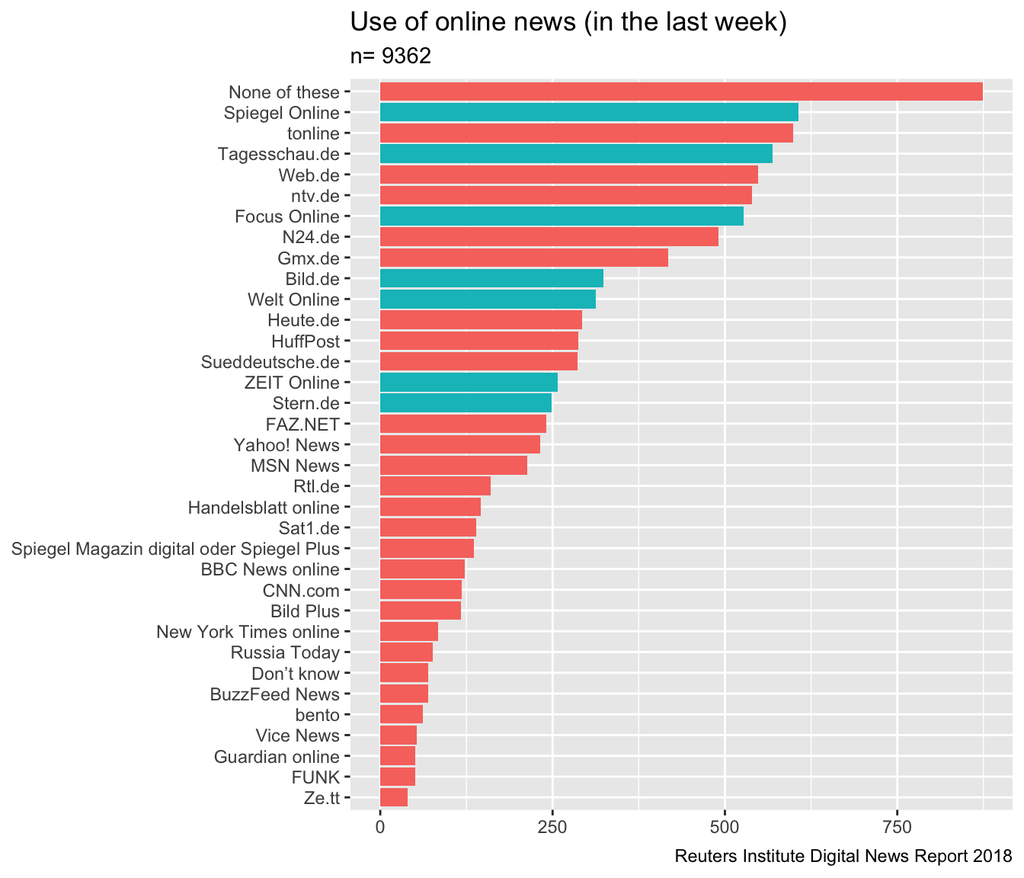

### Political orientation

Q1F. Some people talk about ‘left’, ‘right’ and ‘centre’ to describe parties and politicians. (Generally socialist parties would be considered ‘left wing’ whilst conservative parties would be considered ‘right wing’). With this in mind, where would you place yourself on the following scale?

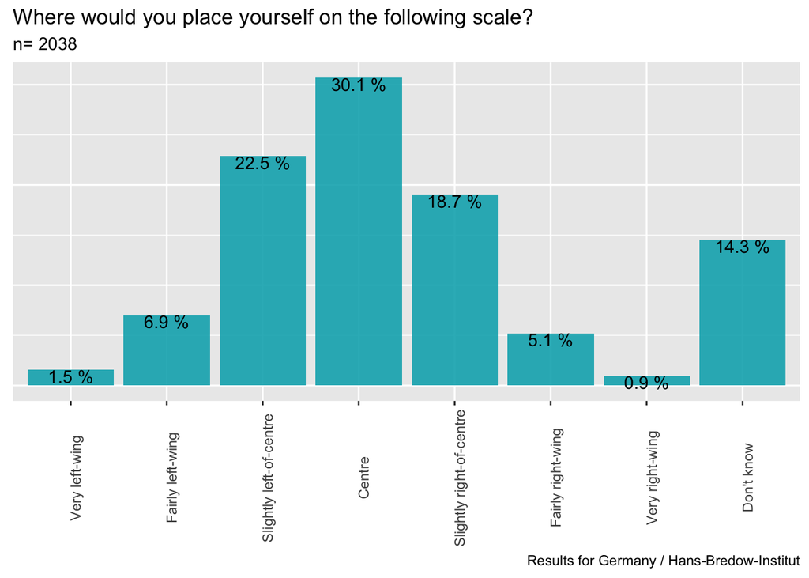

## Combined results

### 7-point Scale

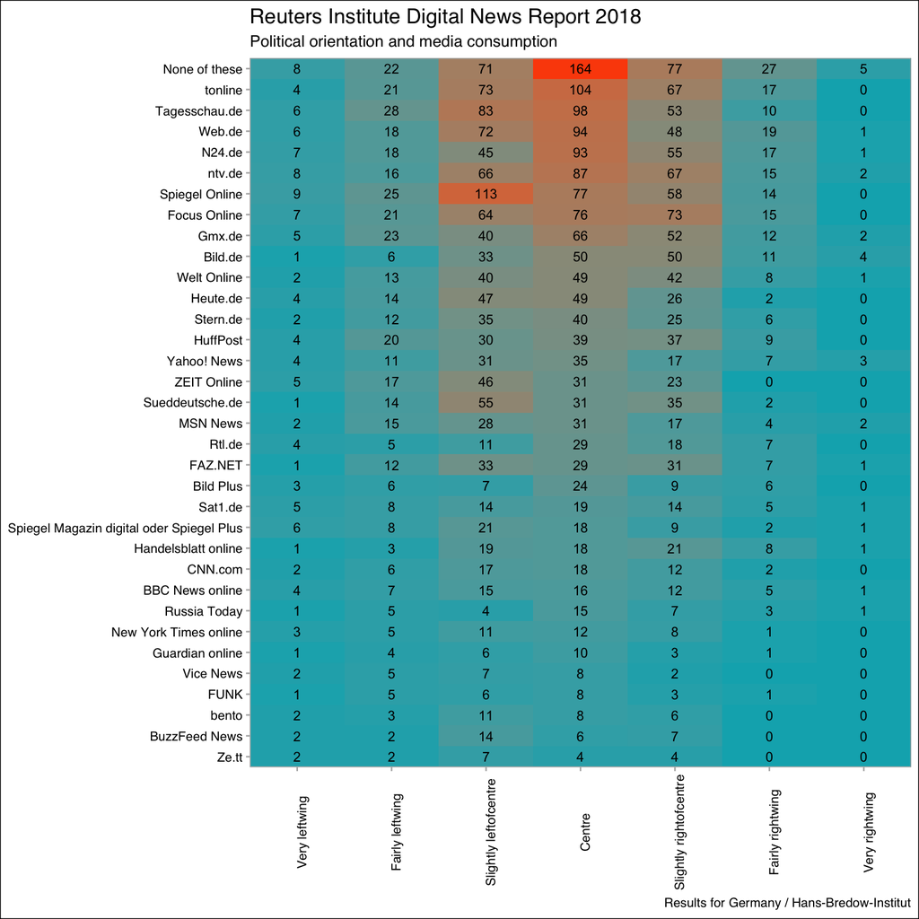

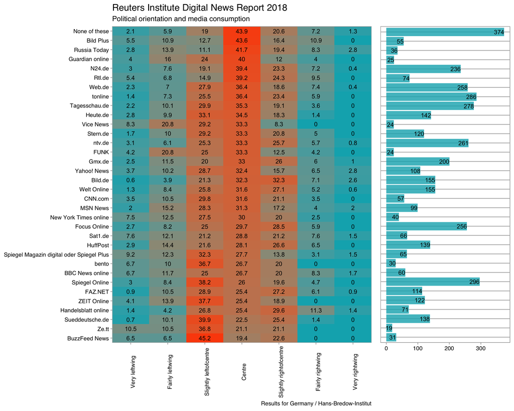

#### News websites included in the model

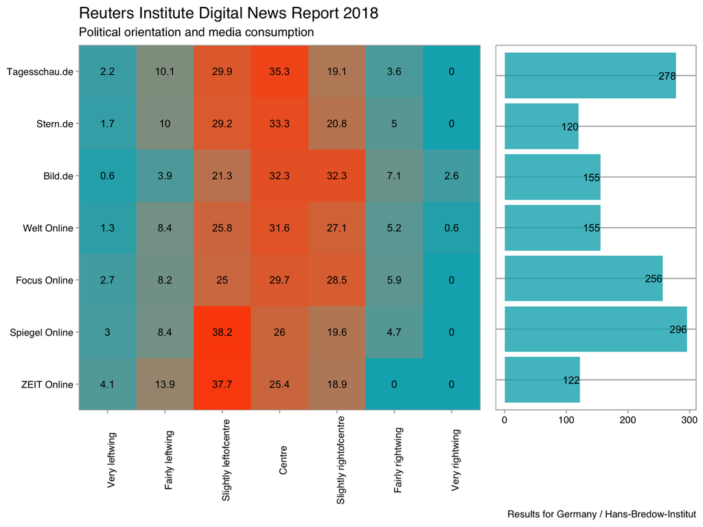

### 3-point scale

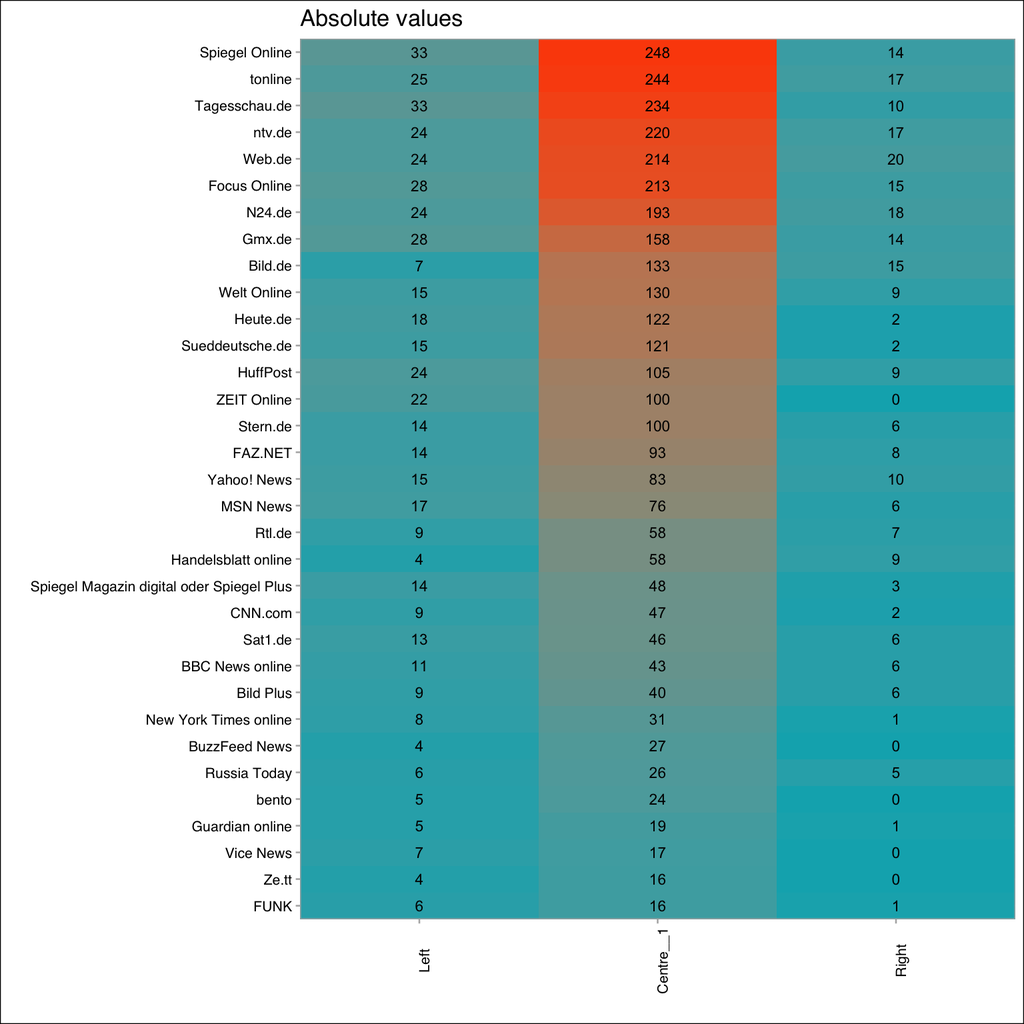

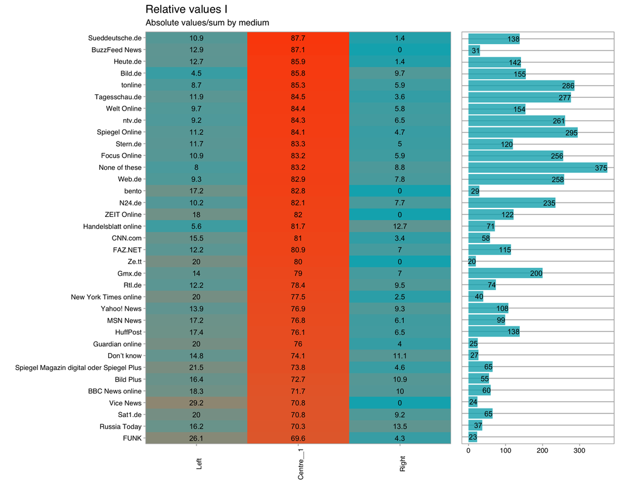

#### News websites included in the model

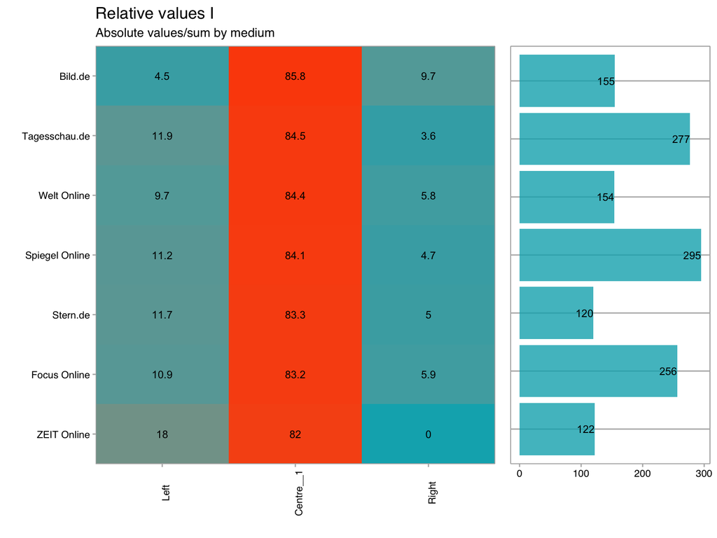